# Barbell Lift Prediction

John McKinzie

04/24/2015

## Summary

In this analysis, I attempted to classify correct barbell lift technique and several common mistakes using kinematic data recorded by various fitness devices. Both Recursive Partitioning and Regression Trees and Random Forest Trees were used. Random Forest was eventually used as the final model. The predictions for the test data ended up being correct when submitted.

## Dataset

The dataset used was collect by [Groupware](http://groupware.les.inf.puc-rio.br/har) (see the section on the Weight Lifting Exercise Dataset). This dataset is licensed under the Creative Commons license (CC BY-SA). The data was generated by the following method:

> Six young health participants were asked to perform one set of 10 repetitions of the Unilateral Dumbbell Biceps Curl in five different fashions: exactly according to the specification (Class A), throwing the elbows to the front (Class B), lifting the dumbbell only halfway (Class C), lowering the dumbbell only halfway (Class D) and throwing the hips to the front (Class E).

```r
# load data
trainingData <- read.csv("pml-training.csv", header = TRUE, na.strings=c("","NA"))
testingData <- read.csv("pml-testing.csv", header = TRUE, na.strings=c("","NA"))
```

```r
# remove metadata and empty/NA columns
trainingData <- trainingData[, -(1:7)]
trainingData <- trainingData[, colSums(is.na(trainingData)) == 0]
testingData <- testingData[, -(1:7)]
testingData <- testingData[, colSums(is.na(testingData)) == 0]
```

After cleaning up the data, there are now 53 variables. Next, I created testing and training partitions from the training data file. Because of the size of the dataset, a 60/40 split was use for training and testing partitions.

```r
# create training and test datasets from training data
set.seed(9991)
inTrain <- createDataPartition(y=trainingData$classe, p=.60, list=FALSE)
trainingSet <- trainingData[inTrain,]
testingSet <- trainingData[-inTrain,]
```

## Recursive Partitioning and Regression Trees

The first model used is a Recursive Partitioning and Regression Trees.

```r
# rpart
modRPart <- train(classe ~ ., method="rpart", data=trainingSet)
predRPart <- predict(modRPart, newdata=testingSet)
confRPart <- confusionMatrix(predRPart, testingSet$classe)
print(confRPart)
```

```
## Confusion Matrix and Statistics
##
##           Reference
## Prediction    A    B    C    D    E
##          A 2025  645  641  586  207
##          B   37  513   37  233  195
##          C  166  360  690  467  393
##          D    0    0    0    0    0
##          E    4    0    0    0  647
##
## Overall Statistics
##
##                Accuracy : 0.4939
##                  95% CI : (0.4828, 0.505)
##     No Information Rate : 0.2845
##     P-Value [Acc > NIR] : < 2.2e-16
##
##                   Kappa : 0.3382
##  Mcnemar's Test P-Value : NA
##
## Statistics by Class:
##
##                      Class: A Class: B Class: C Class: D Class: E
## Sensitivity            0.9073  0.33794  0.50439   0.0000  0.44868
## Specificity            0.6297  0.92067  0.78605   1.0000  0.99938
## Pos Pred Value         0.4934  0.50542  0.33237      NaN  0.99386
## Neg Pred Value         0.9447  0.85288  0.88250   0.8361  0.88951
## Prevalence             0.2845  0.19347  0.17436   0.1639  0.18379
## Detection Rate         0.2581  0.06538  0.08794   0.0000  0.08246
## Detection Prevalence   0.5231  0.12937  0.26459   0.0000  0.08297
## Balanced Accuracy      0.7685  0.62931  0.64522   0.5000  0.72403
```

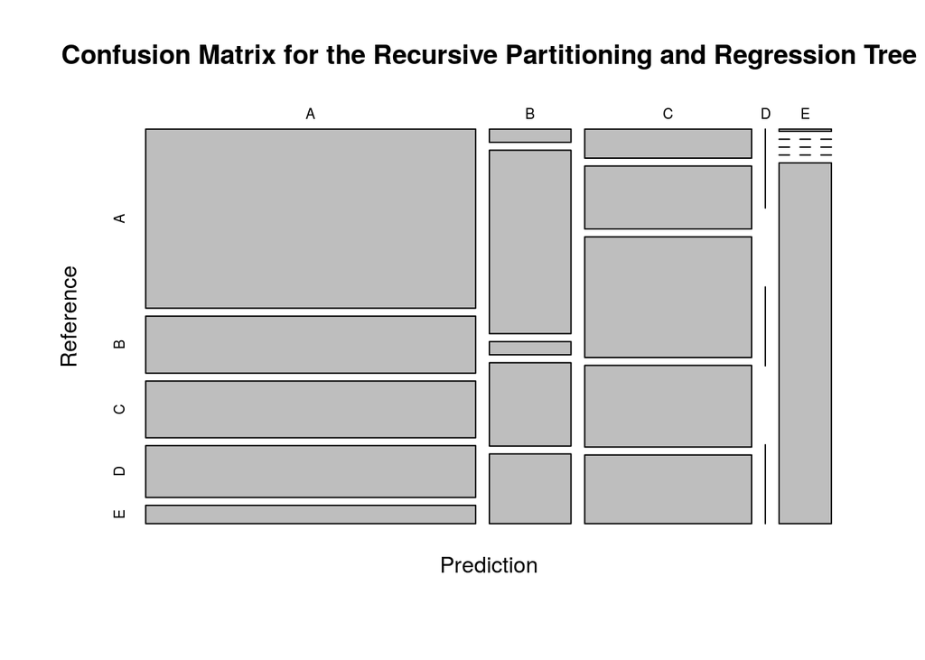

When cross-validating against our test dataset, we can see that the model had an accuracy of 49%. This was less than ideal.

## Random Forest Trees

Since the Recursive Partitioning and Regression Tree did not produce accurate classifications, a Random Forest Tree was used.

```r
# random forest
modRF <- randomForest(classe ~ ., data=trainingData)
print(modRF)
```

```
##
## Call:
##  randomForest(formula = classe ~ ., data = trainingData)
##                Type of random forest: classification
##                      Number of trees: 500
## No. of variables tried at each split: 7
##
##         OOB estimate of  error rate: 0.27%
## Confusion matrix:
##      A    B    C    D    E  class.error
## A 5578    1    0    0    1 0.0003584229
## B   11 3783    3    0    0 0.0036871214
## C    0   11 3411    0    0 0.0032144944
## D    0    0   19 3195    2 0.0065298507
## E    0    0    1    4 3602 0.0013861935
```

The out-of-bag (OOB) error, which is similar to out-of-sample error for when bagging, for this model was 0.27%. This led me to believe this model would be very accurate when applied to our test partition.

```r
predRF <- predict(modRF, newdata = testingSet)
confRF <- confusionMatrix(predRF, testingSet$classe)
```

```
## Confusion Matrix and Statistics
##
##           Reference
## Prediction    A    B    C    D    E
##          A 2232    0    0    0    0
##          B    0 1518    0    0    0
##          C    0    0 1368    0    0
##          D    0    0    0 1286    0
##          E    0    0    0    0 1442
##
## Overall Statistics
##
##                Accuracy : 1
##                  95% CI : (0.9995, 1)
##     No Information Rate : 0.2845
##     P-Value [Acc > NIR] : < 2.2e-16
##
##                   Kappa : 1
##  Mcnemar's Test P-Value : NA
##
## Statistics by Class:
##
##                      Class: A Class: B Class: C Class: D Class: E
## Sensitivity            1.0000   1.0000   1.0000   1.0000   1.0000
## Specificity            1.0000   1.0000   1.0000   1.0000   1.0000
## Pos Pred Value         1.0000   1.0000   1.0000   1.0000   1.0000
## Neg Pred Value         1.0000   1.0000   1.0000   1.0000   1.0000
## Prevalence             0.2845   0.1935   0.1744   0.1639   0.1838
## Detection Rate         0.2845   0.1935   0.1744   0.1639   0.1838
## Detection Prevalence   0.2845   0.1935   0.1744   0.1639   0.1838
## Balanced Accuracy      1.0000   1.0000   1.0000   1.0000   1.0000
```

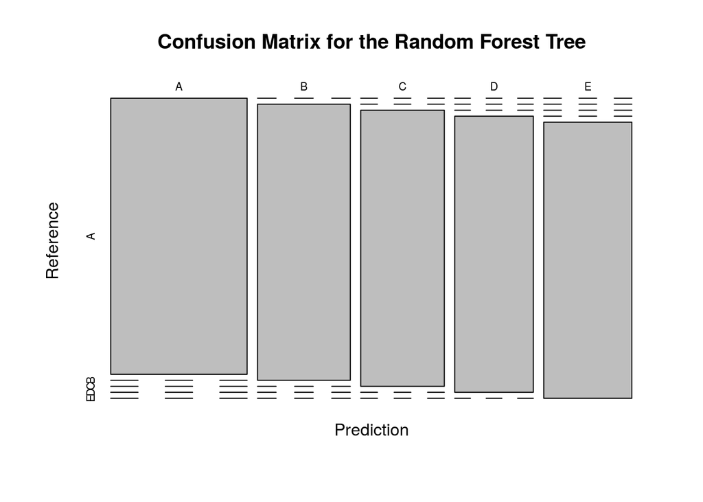

The confusion matrix for the model and test data showed the model was 100% accurate in classifying the test partition of the test data.

## Random Forest Trees with PCA

```r
# random forest w/ pca
modRFPCA <- randomForest(classe ~ ., data=trainingData, preProcess="pca")
print(modRFPCA)
```

```
##
## Call:
##  randomForest(formula = classe ~ ., data = trainingData, preProcess = "pca")
##                Type of random forest: classification
##                      Number of trees: 500
## No. of variables tried at each split: 7
##
##         OOB estimate of  error rate: 0.29%
## Confusion matrix:
##      A    B    C    D    E  class.error
## A 5577    2    0    0    1 0.0005376344
## B   10 3784    3    0    0 0.0034237556
## C    0   12 3408    2    0 0.0040911748
## D    0    0   20 3194    2 0.0068407960
## E    0    0    1    4 3602 0.0013861935
```

```r
predRFPCA <- predict(modRFPCA, newdata = testingSet)
confRFPCA <- confusionMatrix(predRFPCA, testingSet$classe)
```

```
## Confusion Matrix and Statistics
##
##           Reference
## Prediction    A    B    C    D    E
##          A 2232    0    0    0    0
##          B    0 1518    0    0    0
##          C    0    0 1368    0    0
##          D    0    0    0 1286    0
##          E    0    0    0    0 1442
##
## Overall Statistics
##
##                Accuracy : 1
##                  95% CI : (0.9995, 1)
##     No Information Rate : 0.2845
##     P-Value [Acc > NIR] : < 2.2e-16
##
##                   Kappa : 1
##  Mcnemar's Test P-Value : NA
##
## Statistics by Class:
##
##                      Class: A Class: B Class: C Class: D Class: E
## Sensitivity            1.0000   1.0000   1.0000   1.0000   1.0000
## Specificity            1.0000   1.0000   1.0000   1.0000   1.0000
## Pos Pred Value         1.0000   1.0000   1.0000   1.0000   1.0000
## Neg Pred Value         1.0000   1.0000   1.0000   1.0000   1.0000
## Prevalence             0.2845   0.1935   0.1744   0.1639   0.1838
## Detection Rate         0.2845   0.1935   0.1744   0.1639   0.1838
## Detection Prevalence   0.2845   0.1935   0.1744   0.1639   0.1838
## Balanced Accuracy      1.0000   1.0000   1.0000   1.0000   1.0000
```

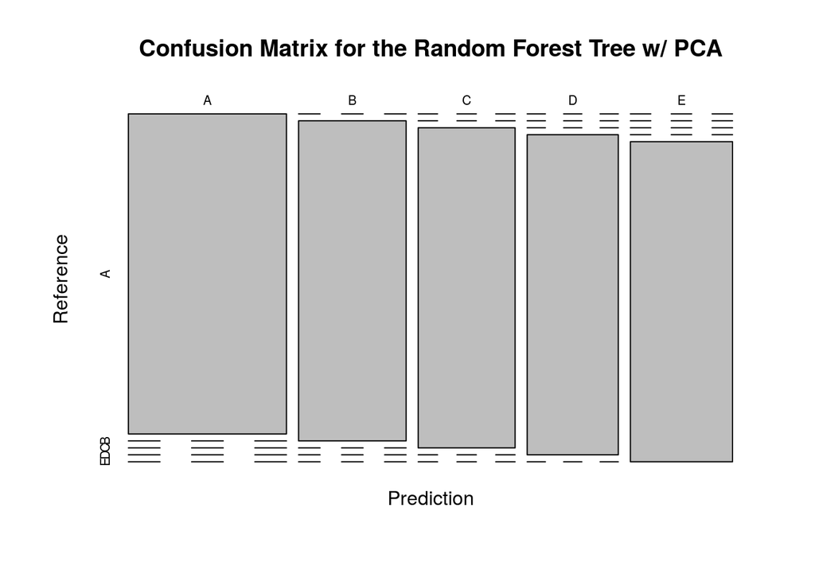

While the OOB error rate was higher, the accuracy of this model was also 100% when apply to the test partition.

## Test Data

```r
predTestRFP <- predict(modRFPCA, newdata=testingData)
print(predTestRFP)
```

```
##  1  2  3  4  5  6  7  8  9 10 11 12 13 14 15 16 17 18 19 20
##  B  A  B  A  A  E  D  B  A  A  B  C  B  A  E  E  A  B  B  B
## Levels: A B C D E
```

## Citations

Velloso, E.; Bulling, A.; Gellersen, H.; Ugulino, W.; Fuks, H. Qualitative Activity Recognition of Weight Lifting Exercises. Proceedings of 4th International Conference in Cooperation with SIGCHI (Augmented Human ’13) . Stuttgart, Germany: ACM SIGCHI, 2013.

Read more: http://groupware.les.inf.puc-rio.br/har#wle_paper_section#ixzz3YLEDMowx